# Bootstrap

Pull yourself up by your bootstraps.

[figure not shown]

## Distribución empírica

Supongamos que tenemos una muestra $X_1,\ldots , X_n\stackrel{\text{i.i.d. }}{\sim}\mathcal{L}(F)$ con $F$ una función de probabilidad cumulativa. Definimos la distribución de probabilidad empírica asociada a estos datos como la ley de probabilidad dada por la función cumulativa de probabilidad

$$F_n(x)=\frac{1}{n}\sum_{i=1}^n\mathbb{1}\left\{ X_i \leq x \right\}.$$

El teorema de Glivenko-Cantelli nos dice que

$$\| F_n - F \|_\infty = \sup_{x\in \mathbb{R}}|F_n(x)-F(x)| \stackrel{\text{c.s.}}{\rightarrow}0$$

Aún más, la desigualdad de Dvoretzky-Kiefer-Wolfowits nos dice que para todo $\epsilon >0$

$$ \mathbb{P}\left[ \sup_{x\in \mathbb{R}}|F_n(x)-F(x)|>\epsilon \right] \leq 2exp\left( -2n\epsilon^2 \right); $$

con lo cual podemos construir bandas de confianza asintóticas.

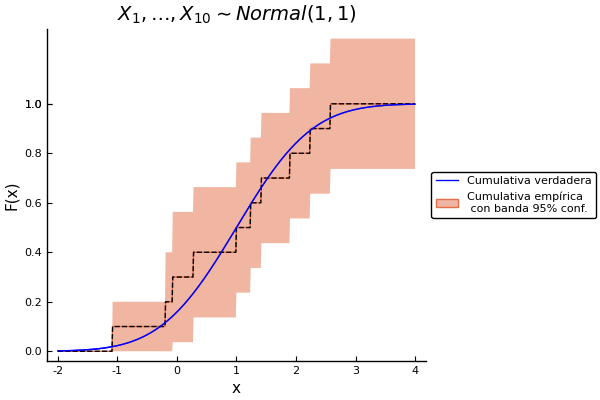

```julia
p
```

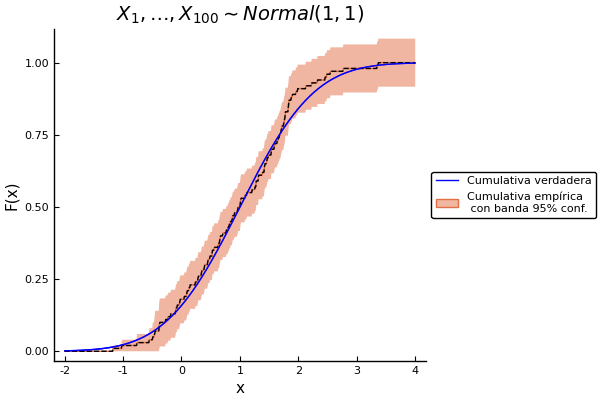

```julia
p
```

## Remuestreo

Observemos que dada una muestra $X_1 \ldots X_n \stackrel{\text{i.i.d.}}{\sim}\mathcal{L}(F)$ con $F$ una función cumulativa de distribución, la distribución empirica correspondiente $\hat{F}_n$ define una ley de probabilidad discreta con un número finito de átomos. Decimos que simulaciones de $\hat{F}_n$ son un remuestreo de la muestra original al poder ser considerados como remuestreo con reemplazo.

Así las cosas si remuestreamos $X_1^\star, \ldots ,X_m^\star\stackrel{\text{i.i.d.}}{\sim}\mathcal{L}(\hat{F}_n)$ entonces

$$ \mathbb{E}_F[h(X_1,\ldots , X_n)] \approx \mathbb{E}_{\hat{F}_n}[h(X_1,\ldots , X_n)] \approx \frac{1}{B} \sum_{i=1}^B h(X_{1,i}^\star,\ldots , X_{n,i}^\star ) $$

con $\left\{ X_{1,i}^\star,\ldots , X_{n,i}^\star \right\}_{i=1}^B$ $B$ remuestreos de $X_1,\ldots , X_n$.

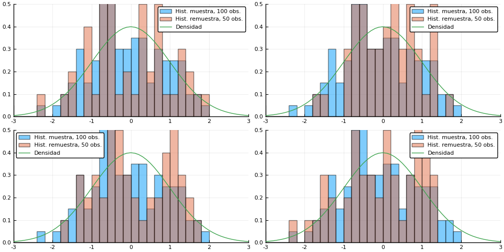

```julia
plot(p1,p2,p3,p4,size=(1000,500))
```

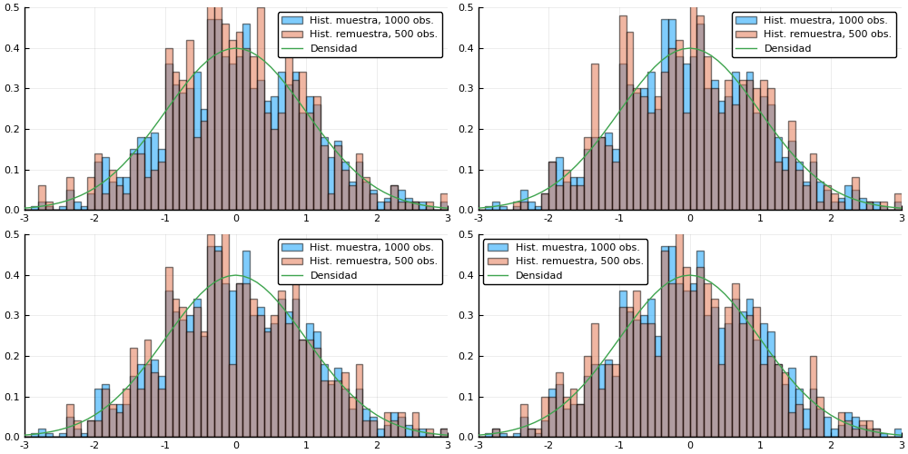

```julia
plot(p1,p2,p3,p4,size=(1000,500))
```

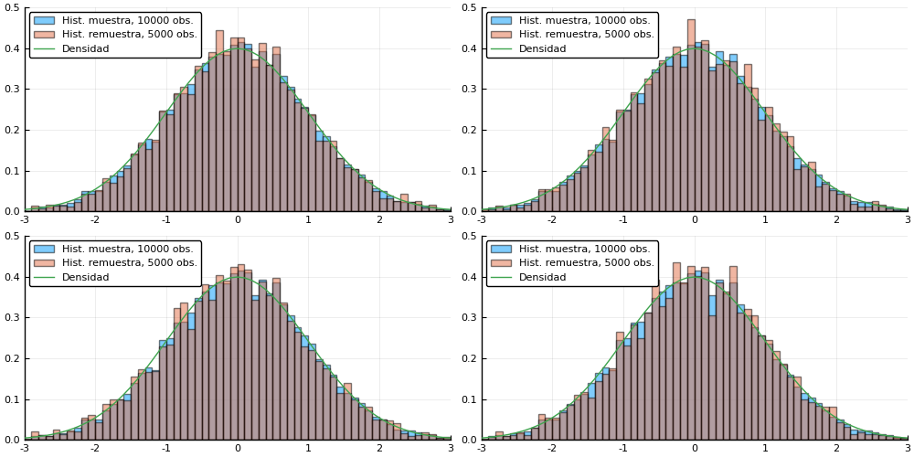

```julia
plot(p1,p2,p3,p4,size=(1000,500))
```

## Bootstrap

La idea es utilizar la distribución empírica para realizar estimaciones vía Monte-Carlo en un contexto de estadística frecuentista. Este método se utiliza usualmente para generar

1) Estimación de la varianza de un estadístico de interés o su desviación estándar, es decir el error estándar.. Por ejemplo para una muestra i.i.d. y $\bar{X}_n=\frac{1}{n}\sum_{i=1}^n X_i$ tenemos $$\text{SE}=\sqrt{ \text{Var}(\bar{X}_n) }=\frac{\sqrt{\text{Var}(X_1)}}{\sqrt{n}}$$.

2) Intervalos de confianza para un estadístico en un contexto frecuentista. Por ejemplo para $\mu=\mathbb{E}[X_1]$ o para el estadístico $$t=\frac{\bar{X}_n-\mu}{\text{SE}}$$

### Algoritmo Bootstrap

Dado una muestra $X_1 \ldots X_n \stackrel{\text{i.i.d.}}{\sim}\mathcal{L}(F)$ con distribución empírica $\hat{F}_n$, $T_n=g(X_1 \ldots X_n)$ un estadístico de interés y $\mathbb{E}[h(T_n)]$ una cantidad a estimar.

0) Fije $B$ un entero positivo y tome $i=1$

1) Remuestre $X_1^\star, \ldots ,X_n^\star\stackrel{\text{i.i.d.}}{\sim}\mathcal{L}(\hat{F}_n)$.

2) Tome $T_{n,i}^\star=g(X_1^\star, \ldots ,X_n^\star)$. Si $i=B$ proceda a 3) en caso contario actualice $i$ a $i+1$ y regrese a 1).

3) Utilice Monte-Carlo con $\left\{ T_{n,i}^\star \right\}_{i=1}$ para estimar $\mathbb{E}[h(T_n)]$.

### Algoritmo Bootstrap para varianza de la media muestral

Dado una muestra $X_1 \ldots X_n \stackrel{\text{i.i.d.}}{\sim}\mathcal{L}(F)$ con distribución empírica $\hat{F}_n$, $\bar{X}_n=\frac{1}{n}\sum_{j=1}^nX_j$ y $\text{Var}(\bar{X}_n)$ la varianza a estimar.

0) Fije $B$ un entero positivo y tome $i=1$

1) Remuestre $X_1^\star, \ldots ,X_n^\star\stackrel{\text{i.i.d.}}{\sim}\mathcal{L}(\hat{F}_n)$.

2) Tome $\bar{X}_{n,i}^\star=\frac{1}{n}\sum_{j=1}^n X_j^\star$. Si $i=B$ proceda a 3) en caso contario actualice $i$ a $i+1$ y regrese a 1).

3) Sea el estimador $$\text{var}_{\text{boot}}=\frac{1}{B}\sum_{i=1}^B\left( \bar{X}_{n,i}^\star - \frac{1}{B}\sum_{j=1}^n \bar{X}_{n,j}^\star \right)^2.$$

### Ejemplo Gamma con muestra de 1000 observaciones

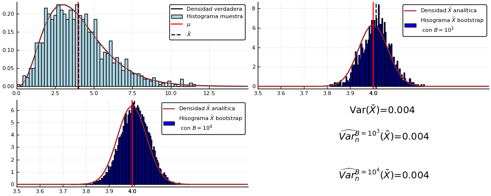

```julia
plot(p_samp,p_boot_1,p_boot_2,plot_a, size=(1000,400))
```

### Ejemplo Gamma con muestra de 10 observaciones

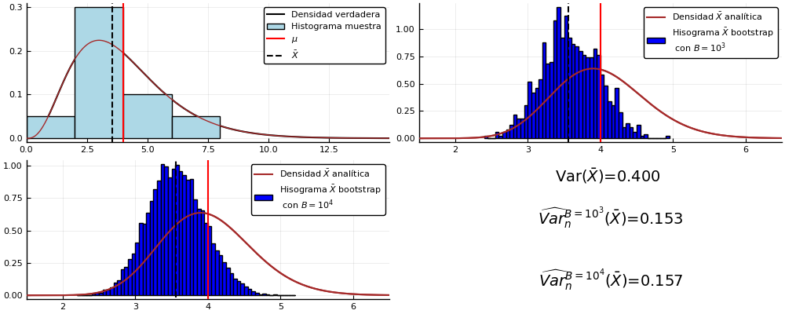

```julia
plot(p_samp,p_boot_1,p_boot_2,plot_a, size=(1000,400))
```

### Ejemplo mixtura Gaussiana con muestra de 50 observaciones

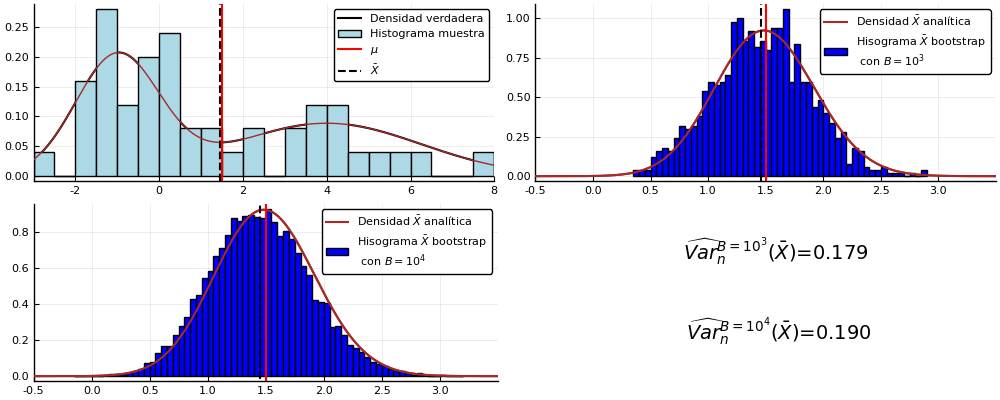

```julia
plot(p_samp,p_boot_1,p_boot_2,plot_a, size=(1000,400))
```

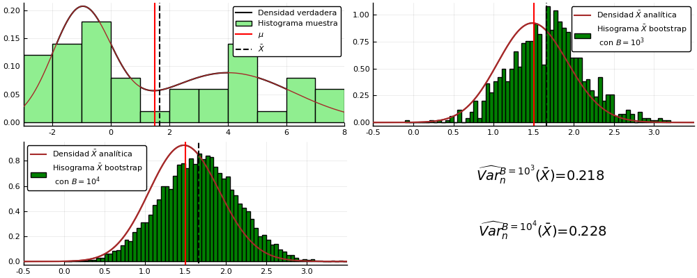

```julia
plot(p_samp,p_boot_1,p_boot_2,plot_a, size=(1000,400))
```

[figure not shown]

```julia
plot(p_samp,p_boot_1,p_boot_2,plot_a, size=(1000,400))
```

### Algoritmo Bootstrap para estadísticos $t$

Dado una muestra $X_1 \ldots X_n \stackrel{\text{i.i.d.}}{\sim}\mathcal{L}(F)$ con $\mu=\mathbb{E}[X_1]$, distribución empírica $\hat{F}_n$, $\bar{X}_n=\frac{1}{n}\sum_{j=1}^nX_j$ y $t=\frac{\bar{X}_n - \mu}{\text{SE}}=\frac{\sqrt{n}(\bar{X}_n - \mu)}{S_n}$ el estadístco para el cual se quiere producir un intervalo de confianza.

0) Fije $B$ un entero positivo y tome $i=1$

1) Remuestre $X_1^\star, \ldots ,X_n^\star\stackrel{\text{i.i.d.}}{\sim}\mathcal{L}(\hat{F}_n)$.

2) Tome $\bar{X}_n^\star = \frac{1}{n}\sum_{j=1}^nX_j^\star$, $S_n^\star=\sqrt{ \frac{1}{n}\sum_{j=1}^n\left(X_j^\star - \bar{X}_n^\star \right)^2}$ y $t_{n,i}^\star=\frac{\sqrt{n}(\bar{X}_n^\star - \bar{X}_n)}{S_n^\star}$. Si $i=B$ proceda a 3) en caso contario actualice $i$ a $i+$ y regrese a 1).

3) Sea el intervalo de confianza $(q_1,q_2)$ con $q_1$ el cuantil emprírico $\alpha/2$ y $q_2$ el cuantil emprírico $1-\alpha/2$ para la muestra $\left\{ t_{n,i}^\star \right\}_{i=1}^B$.

### Ejemplo int. conf. t con muestra expoencial de 50 observaciones

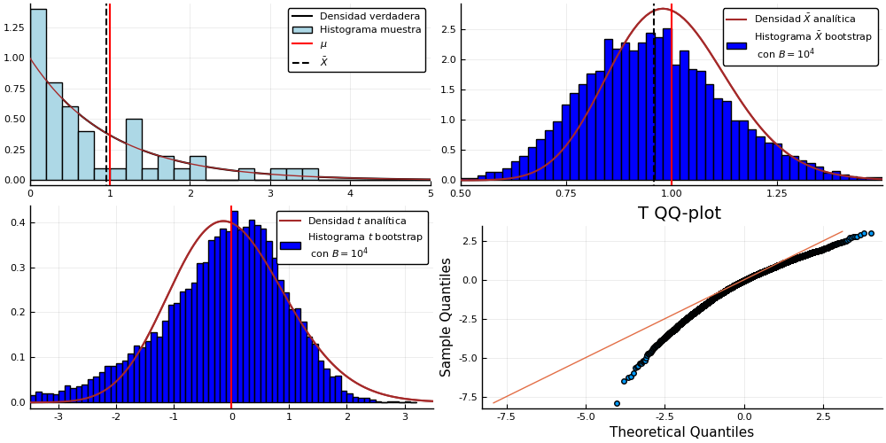

```julia
plot(p_samp,p_boot,p_t_boot,p_qq,size=(1000,500))
```

### Ejemplo int. conf. t con muestra expoencial de 1500 observaciones

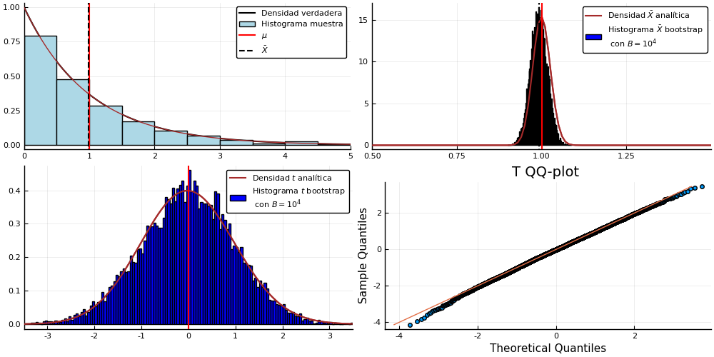

```julia
plot(p_samp,p_boot,p_t_boot,p_qq,size=(1000,500))
```

### Datos reales

Tiempos de espera reparación telefónica.

```julia
R"library(resample)"
R"data(Verizon)"
@rget Verizon
```

|  | Time Float64 | Group Cat… |
| --- | --- | --- |
| 1 | 17.500 | ILEC |
| 2 | 2.400 | ILEC |
| 3 | 0.000 | ILEC |
| 4 | 0.650 | ILEC |
| 5 | 22.230 | ILEC |
| 6 | 1.200 | ILEC |
| 7 | 2.080 | ILEC |
| 8 | 4.970 | ILEC |
| 9 | 0.000 | ILEC |
| 10 | 27.650 | ILEC |
| 11 | 15.670 | ILEC |
| 12 | 0.000 | ILEC |
| 13 | 0.400 | ILEC |
| 14 | 17.850 | ILEC |
| 15 | 22.180 | ILEC |
| 16 | 17.330 | ILEC |
| 17 | 0.000 | ILEC |
| 18 | 0.000 | ILEC |
| 19 | 69.930 | ILEC |
| 20 | 0.000 | ILEC |
| 21 | 0.000 | ILEC |
| 22 | 31.220 | ILEC |
| 23 | 77.170 | ILEC |
| 24 | 0.000 | ILEC |
| 25 | 4.080 | ILEC |
| 26 | 17.480 | ILEC |
| 27 | 24.200 | ILEC |
| 28 | 19.330 | ILEC |
| 29 | 3.520 | ILEC |
| 30 | 0.000 | ILEC |
| ⋮ | ⋮ | ⋮ |

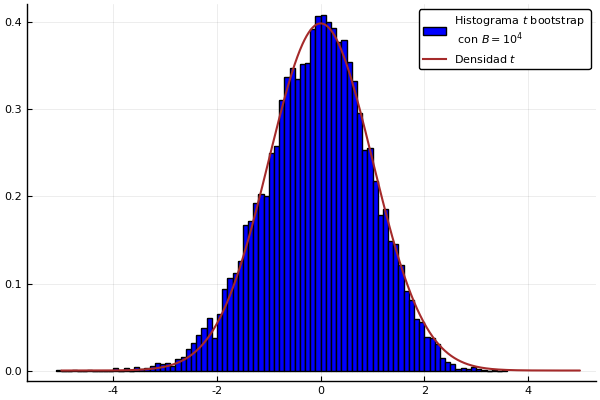

```julia
p2=histogram(t_boot,nbins=100,normalize=true, color=:blue, label="Histograma \$t\$ bootstrap \n con \$B=10^4\$")
plot!( v, [pdf(TDist(n-1),i) for i in v], color=:brown, linewidth=1.5, label="Densidad \$t\$")
```

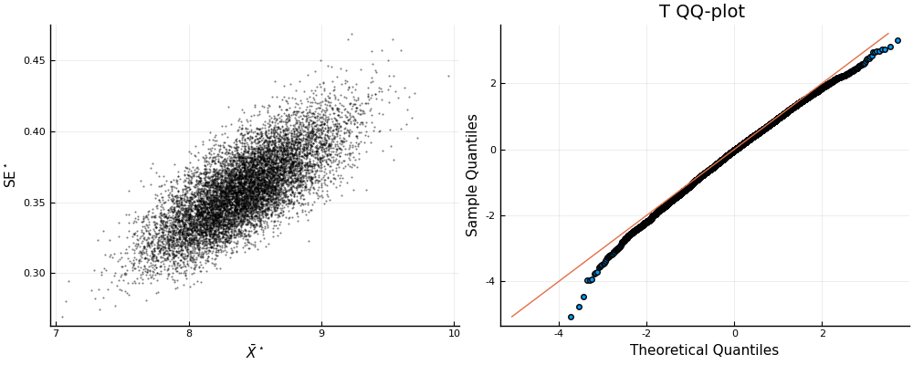

```julia
plot(p1,p3,size=(1000,400))
```